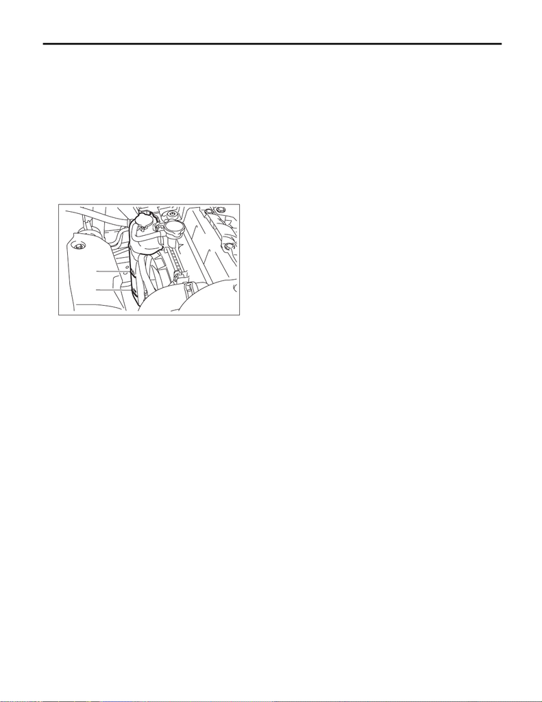

PM-15

Engine Coolant

PERIODIC MAINTENANCE SERVICES

12.Engine Coolant

A: INSPECTION

CAUTION:

• Do not use water instead of coolant.

• Refer to “RM” section for the recommended engine coolant. <Ref. to RM-4, ENGINE COOLANT,

RECOMMENDED MATERIALS, Recommended Materials.>

1) Park the vehicle on a level surface.

2) Make sure the engine coolant level in the reservoir tank is between “FULL” and “LOW” when the engine

is cold.

NOTE:

If the engine coolant level drops, make sure that there are no engine coolant leakage, and add engine cool-

ant to the “FULL” line.

3) Remove the radiator cap and make sure that the radiator is filled with engine coolant up to the filler neck

position.

B: REPLACEMENT

Refer to “CO” section for engine coolant replacement. <Ref. to CO(STI)-13, DRAINING OF ENGINE COOL-

ANT, REPLACEMENT, Engine Coolant.> <Ref. to CO(w/o STI)-13, DRAINING OF ENGINE COOLANT, RE-

PLACEMENT, Engine Coolant.>

PM-00745

FULL

LOW